# Insurance Data Analysis

Rebecca Jun

Spring 2020

## Introduction

The purpose of this data project is to explore variables that may influence medical costs. This data analysis will be conducted by using an insurance data set from Kaggle. Some questions that will be explored include: 1.) How are variables like smoking status, age, gender, body mass index, and one’s location in the United States associated with health care costs? 2.) Which explanatory variable has the most impact on medical costs? 3.) Can health care costs be predicted given these variables? In order to answer these questions, a multiple linear regression and logistic regression will be conducted along with additional data analysis methods.

```r
insurance <- read.csv("insurance.csv")
summary(insurance)
```

```
##       age            sex           bmi           children     smoker
##  Min.   :18.00   female:662   Min.   :15.96   Min.   :0.000   no :1064
##  1st Qu.:27.00   male  :676   1st Qu.:26.30   1st Qu.:0.000   yes: 274
##  Median :39.00                Median :30.40   Median :1.000
##  Mean   :39.21                Mean   :30.66   Mean   :1.095
##  3rd Qu.:51.00                3rd Qu.:34.69   3rd Qu.:2.000
##  Max.   :64.00                Max.   :53.13   Max.   :5.000
##        region       charges
##  northeast:324   Min.   : 1122
##  northwest:325   1st Qu.: 4740
##  southeast:364   Median : 9382
##  southwest:325   Mean   :13270
##                  3rd Qu.:16640
##                  Max.   :63770
```

## Data Description

The data used in this analysis is the Kaggle Medical Cost Data Set. This data set contains 1,338 observations of beneficiaries enrolled in an insurance plan. There are 6 explanatory variables: age, sex (male or female), BMI, number of children or dependents, smoking status (yes or no), and US region (northeast, southeast, southwest, or northwest). Age, BMI, and number of children are continuous explanatory variables. Sex, smoking status, and US region are categorical explanatory variables. The explained or response variable is charges, i.e. individual medical costs billed by health insurance in one year, and it is measured in US dollars.

### Data Preparation.

By using the original variables of the data set, four additional variables were created in order to gain a better understanding of the data set; bmi_status, age_class, charges_class, and smoker_binary were created. The variable bmi_status was created by converting bmi into a categorical variable that consists of underweight, healthy, overweight, and obese according to the criteria in Table 1. The variable age_class was created by converting age into a categorical variable consisting of young_adult (18-34), adult (35-50), and senior (>=51).

#### BMI Status

| **Body Mass Index (BMI)** | **Weight Status** |
| --- | --- |
| < 18.5 | Underweight |
| 18.5 - 24.9 | Healthy |
| 25.0 - 29.9 | Overweight |
| > 30.0 | Obese |

Furthermore, charges_class was created by converting charges into a categorical variable consisting of low (charges less than mean value $13,270) and high (charges greater than mean). The variable smoker_binary was created by converting smoker into a binary variable, where being a smoker equals 1 and 0 otherwise; smoker_binary will be utilized in the logistic regression section.

#### Age Class

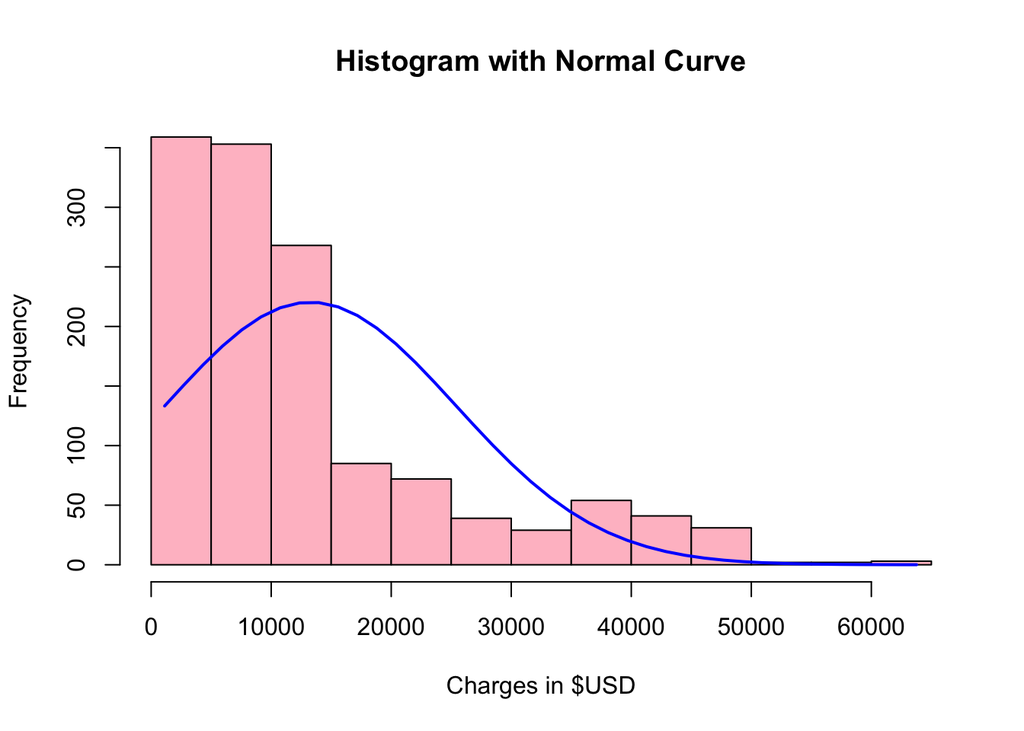

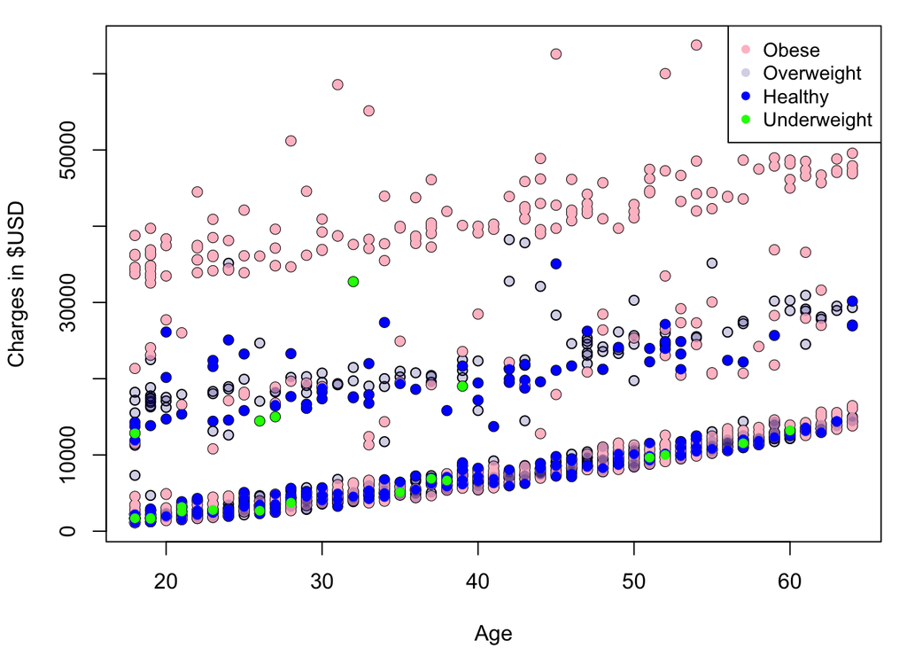

```r
cor(insurance$bmi, insurance$charges)
```

```
## [1] 0.198341
```

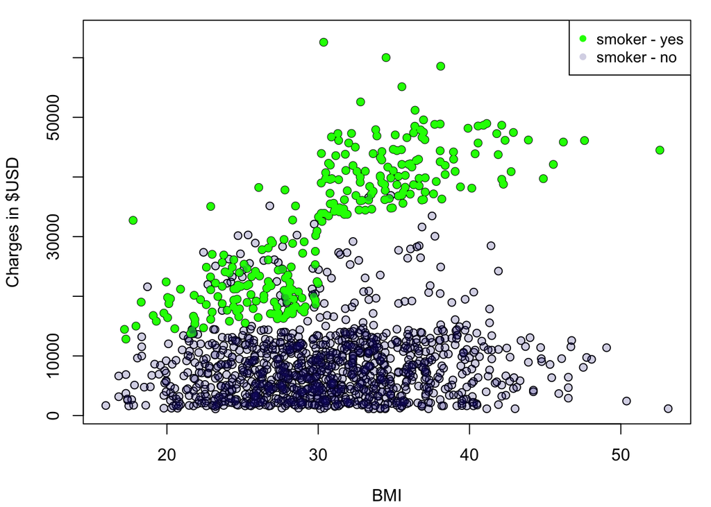

[figure not shown]

```r
par(mar=c(4.1,4.1,1,1))
plot(insurance$bmi, insurance$charges, xlab = "BMI", ylab = "Charges in $USD")
smoker_yes <- which(insurance$smoker == "yes")
points(insurance$bmi[smoker_yes], insurance$charges[smoker_yes], pch = 16, col = "green")
smoker_no <- which(insurance$smoker == "no")
points(insurance$bmi[smoker_no], insurance$charges[smoker_no], pch = 16, col = rgb(0.1,0.1,0.5,0.2))
legend("topright", legend = c("smoker - yes", "smoker - no"), col = c("green", rgb(0.1,0.1,0.5,0.2)),
       pch=16, cex = 0.9)
```

```r
cor(insurance[c("age", "bmi", "children", "charges")])
```

```
##                age       bmi   children    charges
## age      1.0000000 0.1092719 0.04246900 0.29900819
## bmi      0.1092719 1.0000000 0.01275890 0.19834097
## children 0.0424690 0.0127589 1.00000000 0.06799823
## charges  0.2990082 0.1983410 0.06799823 1.00000000
```

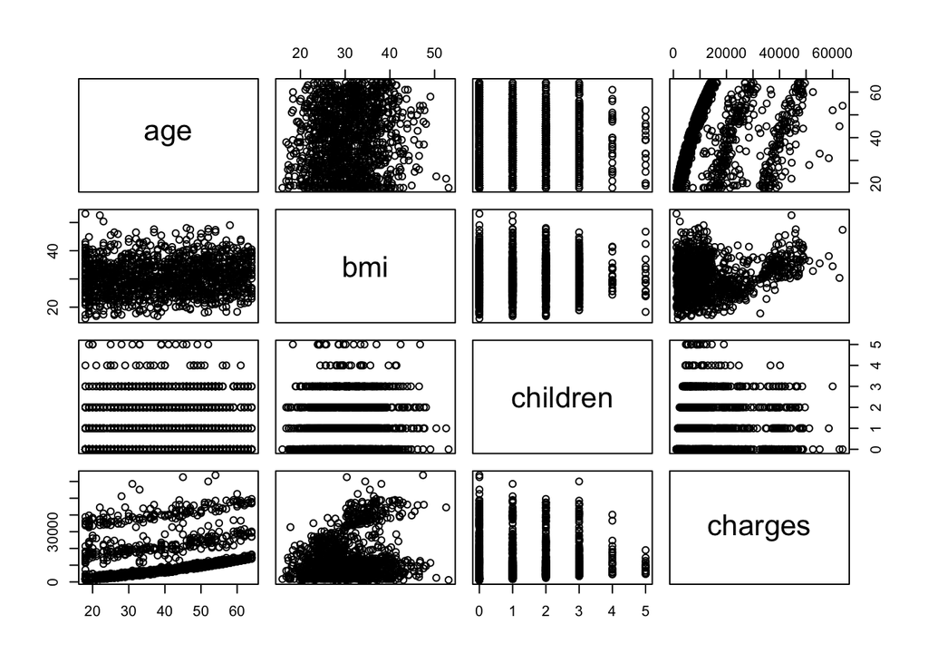

```r
pairs(insurance[c("age", "bmi", "children", "charges")])
```

## Principal Component Analysis

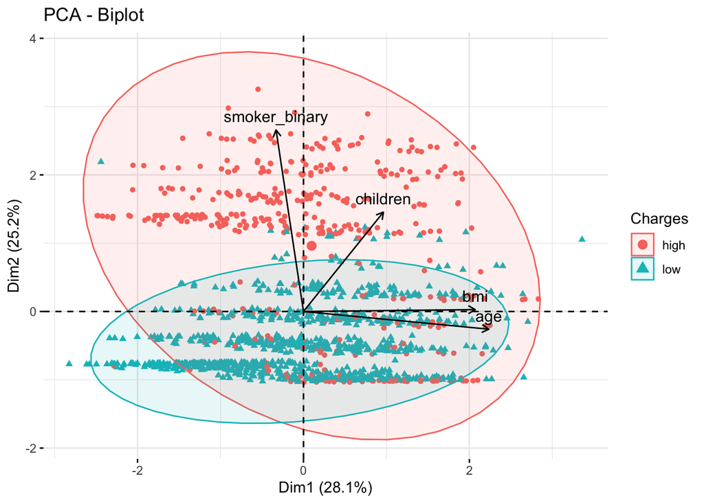

```
## Importance of components:
##                           PC1    PC2    PC3    PC4
## Standard deviation     1.0598 1.0033 0.9938 0.9394
## Proportion of Variance 0.2808 0.2517 0.2469 0.2206
## Cumulative Proportion  0.2808 0.5325 0.7794 1.0000
```

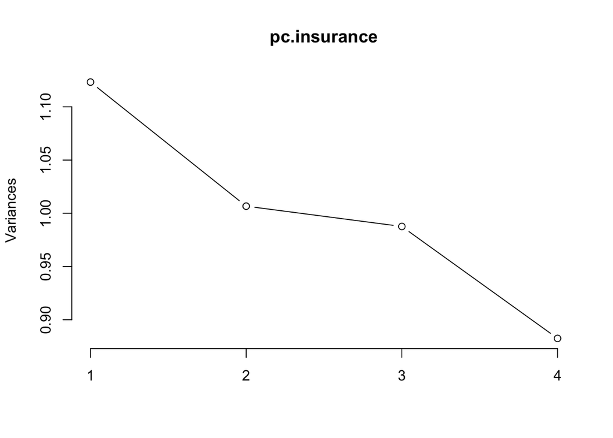

## Regression Analysis

```r
reg <- lm(charges~age+bmi+children+sex+smoker+region, data = insurance)
summary(reg)
```

```
##
## Call:
## lm(formula = charges ~ age + bmi + children + sex + smoker +
##     region, data = insurance)
##
## Residuals:
##      Min       1Q   Median       3Q      Max
## -11304.9  -2848.1   -982.1   1393.9  29992.8
##
## Coefficients:
##                 Estimate Std. Error t value Pr(>|t|)
## (Intercept)     -11938.5      987.8 -12.086  < 2e-16 ***
## age                256.9       11.9  21.587  < 2e-16 ***
## bmi                339.2       28.6  11.860  < 2e-16 ***
## children           475.5      137.8   3.451 0.000577 ***
## sexmale           -131.3      332.9  -0.394 0.693348
## smokeryes        23848.5      413.1  57.723  < 2e-16 ***
## regionnorthwest   -353.0      476.3  -0.741 0.458769
## regionsoutheast  -1035.0      478.7  -2.162 0.030782 *
## regionsouthwest   -960.0      477.9  -2.009 0.044765 *
## ---
## Signif. codes:  0 '***' 0.001 '**' 0.01 '*' 0.05 '.' 0.1 ' ' 1
##
## Residual standard error: 6062 on 1329 degrees of freedom
## Multiple R-squared:  0.7509, Adjusted R-squared:  0.7494
## F-statistic: 500.8 on 8 and 1329 DF,  p-value: < 2.2e-16
```

```r
reg1 <- lm(charges~age+bmi+children+smoker+region, data = insurance)
summary(reg1)
```

```
##
## Call:
## lm(formula = charges ~ age + bmi + children + smoker + region,
##     data = insurance)
##
## Residuals:
##      Min       1Q   Median       3Q      Max
## -11367.2  -2835.4   -979.7   1361.9  29935.5
##
## Coefficients:
##                  Estimate Std. Error t value Pr(>|t|)
## (Intercept)     -11990.27     978.76 -12.250  < 2e-16 ***
## age                256.97      11.89  21.610  < 2e-16 ***
## bmi                338.66      28.56  11.858  < 2e-16 ***
## children           474.57     137.74   3.445 0.000588 ***
## smokeryes        23836.30     411.86  57.875  < 2e-16 ***
## regionnorthwest   -352.18     476.12  -0.740 0.459618
## regionsoutheast  -1034.36     478.54  -2.162 0.030834 *
## regionsouthwest   -959.37     477.78  -2.008 0.044846 *
## ---
## Signif. codes:  0 '***' 0.001 '**' 0.01 '*' 0.05 '.' 0.1 ' ' 1
##
## Residual standard error: 6060 on 1330 degrees of freedom
## Multiple R-squared:  0.7509, Adjusted R-squared:  0.7496
## F-statistic: 572.7 on 7 and 1330 DF,  p-value: < 2.2e-16
```

## Logistic Regression

```r
# smoker_dummy
insurance$smoker_yes[insurance$smoker == "yes"] <- 1
insurance$smoker_yes[insurance$smoker == "no"] <- 0
insurance$smoker_yes <- as.factor(insurance$smoker_yes)
summary(insurance$smoker_yes)
```

```
##    0    1
## 1064  274
```

```r
# convert continuous variable into a binary variable
insurance$binary <- as.numeric(insurance$charges > mean(insurance$charges))
insurance$binary
```

[output not shown]

[output cut: 22 more lines]

```r
logistic <- glm((binary==1) ~ bmi + age + children + smoker + region,
                 data=insurance, family="binomial")
summary(logistic)
```

```
##
## Call:
## glm(formula = (binary == 1) ~ bmi + age + children + smoker +
##     region, family = "binomial", data = insurance)
##
## Deviance Residuals:
##      Min        1Q    Median        3Q       Max
## -3.09091  -0.54554  -0.29395   0.04863   2.88772
##
## Coefficients:
##                 Estimate Std. Error z value Pr(>|z|)
## (Intercept)     -5.42349    0.63493  -8.542  < 2e-16 ***
## bmi              0.01736    0.01629   1.065   0.2867
## age              0.07143    0.00816   8.754  < 2e-16 ***
## children         0.12162    0.07542   1.613   0.1068
## smokeryes        8.36280    1.02460   8.162  3.3e-16 ***
## regionnorthwest -0.15705    0.25607  -0.613   0.5397
## regionsoutheast -0.20187    0.26245  -0.769   0.4418
## regionsouthwest -0.66209    0.27537  -2.404   0.0162 *
## ---
## Signif. codes:  0 '***' 0.001 '**' 0.01 '*' 0.05 '.' 0.1 ' ' 1
##
## (Dispersion parameter for binomial family taken to be 1)
##
##     Null deviance: 1664.97  on 1337  degrees of freedom
## Residual deviance:  758.94  on 1330  degrees of freedom
## AIC: 774.94
##
## Number of Fisher Scoring iterations: 8
```

```r
coef(logistic)
```

```
##     (Intercept)             bmi             age        children       smokeryes
##     -5.42348977      0.01735592      0.07143262      0.12162141      8.36279467
## regionnorthwest regionsoutheast regionsouthwest
##     -0.15705027     -0.20186599     -0.66208788
```

```r
p.hat <- fitted(logistic)
y.hat <- round(p.hat)
```